# Part I - (ProsperLoans Data)

## by (Aibangbee Darlington)

## Introduction

> The Prosper Loans data set contains 113,937 loans with 81 variables on each loan, including loan amount, borrower rate (or interest rate), current loan status, borrower income, and many others.

> This dataset is analysed to answer questions like:
> - What factors affect a loan’s outcome status?
> - What affects the borrower’s APR or interest rate?
> - Are there differences between loans depending on how large the original loan amount was?

>   > Some of the important features considered in this analysis are defined and explained below. For a full definition of all the features contained in this dataset, this data dictionary explains the variables in the data set. You are not expected to explore all of the variables in the dataset! Focus your exploration on about 10-15 of them.

## Preliminary Wrangling

```python
# import all packages and set plots to be embedded inline
import numpy as np
import pandas as pd
import matplotlib.pyplot as plt
import seaborn as sb

%matplotlib inline
```

```python
!pip install seaborn --upgrade
```

[output not shown]

```python
loans = pd.read_csv('prosperLoanData.csv')
```

```python
loans.info()
```

```
<class 'pandas.core.frame.DataFrame'>
RangeIndex: 113937 entries, 0 to 113936
Data columns (total 81 columns):
ListingKey                             113937 non-null object
ListingNumber                          113937 non-null int64
ListingCreationDate                    113937 non-null object
CreditGrade                            28953 non-null object
Term                                   113937 non-null int64
LoanStatus                             113937 non-null object
ClosedDate                             55089 non-null object
BorrowerAPR                            113912 non-null float64
BorrowerRate                           113937 non-null float64
LenderYield                            113937 non-null float64
EstimatedEffectiveYield                84853 non-null float64
EstimatedLoss                          84853 non-null float64
EstimatedReturn                        84853 non-null float64
ProsperRating (numeric)                84853 non-null float64
ProsperRating (Alpha)                  84853 non-null object
ProsperScore                           84853 non-null float64
ListingCategory (numeric)              113937 non-null int64
BorrowerState                          108422 non-null object
Occupation                             110349 non-null object
EmploymentStatus                       111682 non-null object
EmploymentStatusDuration               106312 non-null float64
IsBorrowerHomeowner                    113937 non-null bool
CurrentlyInGroup                       113937 non-null bool
GroupKey                               13341 non-null object
DateCreditPulled                       113937 non-null object
CreditScoreRangeLower                  113346 non-null float64
CreditScoreRangeUpper                  113346 non-null float64
FirstRecordedCreditLine                113240 non-null object
CurrentCreditLines                     106333 non-null float64
OpenCreditLines                        106333 non-null float64
TotalCreditLinespast7years             113240 non-null float64
OpenRevolvingAccounts                  113937 non-null int64
OpenRevolvingMonthlyPayment            113937 non-null float64
InquiriesLast6Months                   113240 non-null float64
TotalInquiries                         112778 non-null float64
CurrentDelinquencies                   113240 non-null float64
AmountDelinquent                       106315 non-null float64
```

[output cut: 31 more lines]

```
LP_CustomerPayments                    113937 non-null float64
LP_CustomerPrincipalPayments           113937 non-null float64
LP_InterestandFees                     113937 non-null float64
LP_ServiceFees                         113937 non-null float64
LP_CollectionFees                      113937 non-null float64
LP_GrossPrincipalLoss                  113937 non-null float64
LP_NetPrincipalLoss                    113937 non-null float64
LP_NonPrincipalRecoverypayments        113937 non-null float64
PercentFunded                          113937 non-null float64
Recommendations                        113937 non-null int64
InvestmentFromFriendsCount             113937 non-null int64
InvestmentFromFriendsAmount            113937 non-null float64
Investors                              113937 non-null int64
dtypes: bool(3), float64(50), int64(11), object(17)
memory usage: 68.1+ MB
```

```python
# Dataframe of Features of Interest(foi)
foi = loans[['ListingNumber', 'ListingCreationDate', 'CreditGrade', 'Term', 'LoanStatus', 'CurrentCreditLines', 'OpenCreditLines', 'ClosedDate','LoanOriginalAmount', 'BorrowerAPR', 'BorrowerRate', 'ProsperRating (Alpha)', 'ProsperRating (numeric)', 'ListingCategory (numeric)', 'BorrowerState', 'Occupation', 'EmploymentStatus', 'EmploymentStatusDuration', 'CreditScoreRangeLower', 'CreditScoreRangeUpper', 'DebtToIncomeRatio', 'OpenCreditLines', 'IsBorrowerHomeowner', 'IncomeRange', 'StatedMonthlyIncome', 'TotalProsperLoans', 'OnTimeProsperPayments', 'ProsperPaymentsLessThanOneMonthLate', 'ProsperPaymentsOneMonthPlusLate', 'ProsperPrincipalBorrowed', 'ProsperPrincipalOutstanding']]
```

```python
foi.describe()
```

|  | ListingNumber | Term | CurrentCreditLines | OpenCreditLines | LoanOriginalAmount | BorrowerAPR | BorrowerRate | ProsperRating (numeric) | ListingCategory (numeric) | EmploymentStatusDuration | ... | CreditScoreRangeUpper | DebtToIncomeRatio | OpenCreditLines | StatedMonthlyIncome | TotalProsperLoans | OnTimeProsperPayments | ProsperPaymentsLessThanOneMonthLate | ProsperPaymentsOneMonthPlusLate | ProsperPrincipalBorrowed | ProsperPrincipalOutstanding |
| --- | --- | --- | --- | --- | --- | --- | --- | --- | --- | --- | --- | --- | --- | --- | --- | --- | --- | --- | --- | --- | --- |
| count | 1.139370e+05 | 113937.000000 | 106333.000000 | 106333.000000 | 113937.00000 | 113912.000000 | 113937.000000 | 84853.000000 | 113937.000000 | 106312.000000 | ... | 113346.000000 | 105383.000000 | 106333.000000 | 1.139370e+05 | 22085.000000 | 22085.000000 | 22085.000000 | 22085.000000 | 22085.000000 | 22085.000000 |
| mean | 6.278857e+05 | 40.830248 | 10.317192 | 9.260164 | 8337.01385 | 0.218828 | 0.192764 | 4.072243 | 2.774209 | 96.071582 | ... | 704.567731 | 0.275947 | 9.260164 | 5.608026e+03 | 1.421100 | 22.271949 | 0.613629 | 0.048540 | 8472.311961 | 2930.313906 |
| std | 3.280762e+05 | 10.436212 | 5.457866 | 5.022644 | 6245.80058 | 0.080364 | 0.074818 | 1.673227 | 3.996797 | 94.480605 | ... | 66.458275 | 0.551759 | 5.022644 | 7.478497e+03 | 0.764042 | 18.830425 | 2.446827 | 0.556285 | 7395.507650 | 3806.635075 |
| min | 4.000000e+00 | 12.000000 | 0.000000 | 0.000000 | 1000.00000 | 0.006530 | 0.000000 | 1.000000 | 0.000000 | 0.000000 | ... | 19.000000 | 0.000000 | 0.000000 | 0.000000e+00 | 0.000000 | 0.000000 | 0.000000 | 0.000000 | 0.000000 | 0.000000 |
| 25% | 4.009190e+05 | 36.000000 | 7.000000 | 6.000000 | 4000.00000 | 0.156290 | 0.134000 | 3.000000 | 1.000000 | 26.000000 | ... | 679.000000 | 0.140000 | 6.000000 | 3.200333e+03 | 1.000000 | 9.000000 | 0.000000 | 0.000000 | 3500.000000 | 0.000000 |
| 50% | 6.005540e+05 | 36.000000 | 10.000000 | 9.000000 | 6500.00000 | 0.209760 | 0.184000 | 4.000000 | 1.000000 | 67.000000 | ... | 699.000000 | 0.220000 | 9.000000 | 4.666667e+03 | 1.000000 | 15.000000 | 0.000000 | 0.000000 | 6000.000000 | 1626.550000 |
| 75% | 8.926340e+05 | 36.000000 | 13.000000 | 12.000000 | 12000.00000 | 0.283810 | 0.250000 | 5.000000 | 3.000000 | 137.000000 | ... | 739.000000 | 0.320000 | 12.000000 | 6.825000e+03 | 2.000000 | 32.000000 | 0.000000 | 0.000000 | 11000.000000 | 4126.720000 |
| max | 1.255725e+06 | 60.000000 | 59.000000 | 54.000000 | 35000.00000 | 0.512290 | 0.497500 | 7.000000 | 20.000000 | 755.000000 | ... | 899.000000 | 10.010000 | 54.000000 | 1.750003e+06 | 8.000000 | 141.000000 | 42.000000 | 21.000000 | 72499.000000 | 23450.950000 |

8 rows × 21 columns

### Structure of the ProsperLoans dataset?

> The ProsperLoans Dataset contains 113937 loan entries under grouped under 81 features(columns) some of which are very important factors that affect or explains the circumstances surrounding a loan issue or status. These features contains information on things like:
> - Loan Type, Amount, Date, Interest Rate
> - Borrower financial information: Occupation, Employment Status, Credit score, income range
> - Loan information: Status

Some of the key Columns or Features that could potentially answer some key questions on visualisation are:

```
 Variable   Description
```

- **ListingNumber:** The number that uniquely identifies the listing to the public as displayed on the website.
- **ListingCreationDate:** The date the listing was created.
- **CreditGrade:** The Credit rating that was assigned at the time the listing went live. Applicable for listings pre-2009 period and will only be populated for those listings.
- **Term:** The length of the loan expressed in months.
- **LoanStatus:** The current status of the loan: Cancelled, Chargedoff, Completed, Current, Defaulted, FinalPaymentInProgress, PastDue. The PastDue status will be accompanied by a delinquency bucket.
- **ClosedDate:** Closed date is applicable for Cancelled, Completed, Chargedoff and Defaulted loan statuses.
- **BorrowerAPR:** The Borrower's Annual Percentage Rate (APR) for the loan.
- **BorrowerRate:** The Borrower's interest rate for this loan.
- **LenderYield:** The Lender yield on the loan. Lender yield is equal to the interest rate on the loan less the servicing fee.
- **ProsperRating (Alpha):** The Prosper Rating assigned at the time the listing was created between AA - HR. Applicable for loans originated after July 2009.
- **ProsperScore:** A custom risk score built using historical Prosper data. The score ranges from 1-10, with 10 being the best, or lowest risk score. Applicable for loans originated after July 2009.
- **ListingCategory:** The category of the listing that the borrower selected when posting their listing: 0 - Not Available, 1 - Debt Consolidation, 2 - Home Improvement, 3 - Business, 4 - Personal Loan, 5 - Student Use, 6 - Auto, 7- Other, 8 - Baby&Adoption, 9 - Boat, 10 - Cosmetic Procedure, 11 - Engagement Ring, 12 - Green Loans, 13 - Household Expenses, 14 - Large Purchases, 15 - Medical/Dental, 16 - Motorcycle, 17 - RV, 18 - Taxes, 19 - Vacation, 20 - Wedding Loans
- **BorrowerState:** The two letter abbreviation of the state of the address of the borrower at the time the Listing was created.
- **Occupation:** The Occupation selected by the Borrower at the time they created the listing.
- **EmploymentStatus:** The employment status of the borrower at the time they posted the listing.
- **EmploymentStatusDuration:** The length in months of the employment status at the time the listing was created.
- **IsBorrowerHomeowner:** A Borrower will be classified as a homowner if they have a mortgage on their credit profile or provide documentation confirming they are a homeowner.
- **CreditScoreRangeLower:** The lower value representing the range of the borrower's credit score as provided by a consumer credit rating agency.
- **CreditScoreRangeUpper:** The upper value representing the range of the borrower's credit score as provided by a consumer credit rating agency.
- **CurrentCreditLines:** Number of current credit lines at the time the credit profile was pulled.
- **OpenCreditLines:** Number of open credit lines at the time the credit profile was pulled.
- **DelinquenciesLast7Years:** Number of delinquencies in the past 7 years at the time the credit profile was pulled.
- **AvailableBankcardCredit:** The total available credit via bank card at the time the credit profile was pulled.
- **DebtToIncomeRatio:** The debt to income ratio of the borrower at the time the credit profile was pulled. This value is Null if the debt to income ratio is not available. This value is capped at 10.01 (any debt to income ratio larger than 1000% will be returned as 1001%).
- **IncomeRange:** The income range of the borrower at the time the listing was created.
- **IncomeVerifiable:** The borrower indicated they have the required documentation to support their income.
- **StatedMonthlyIncome:** The monthly income the borrower stated at the time the listing was created.
- **OnTimeProsperPayments:** Number of on time payments the borrower had made on Prosper loans at the time they created this listing. This value will be null if the borrower has no prior loans.
- **ProsperPaymentsLessThanOneMonthLate:** Number of payments the borrower made on Prosper loans that were less than one month late at the time they created this listing. This value will be null if the borrower had no prior loans.
- **ProsperPaymentsOneMonthPlusLate:** Number of payments the borrower made on Prosper loans that were greater than one month late at the time they created this listing. This value will be null if the borrower had no prior loans.
- **LoanOriginalAmount:** The origination amount of the loan.
- **LoanOriginationDate:** The date the loan was originated.
- **LoanOriginationQuarter:** The quarter in which the loan was originated.
- **MonthlyLoanPayment:** The scheduled monthly loan payment.
- **Investors:** The number of investors that funded the loan.

### Main feature(s) of interest in your dataset?

> The main features of Interest in my DataSet are:
> - BorrowerRate(interest Rate on loans), BorrowerAPR(annual interest on loans), LoanStatus(outcome on the loan), Type of Loans(ListingCategory)

### Features in the dataset that will most likely help support the investigation into feature(s) of interest?

> The features in the dataset that may help in my investigation are features like
> - The borrowers financial information features like: Occupation, EmploymentStatus, CreditScoreRange, CurrentCreditLines BorrowerRAte, DebtToIncomeRatio, IncomeRange, StatedMonthly income!
> - The Loan features like: amount, Term, BorrowerAPR, BorrowerRAte, ProsperRating, LenderYield, EstimatedEffectiveYield

## Univariate Exploration

> In this section, investigate distributions of individual variables. If you see unusual points or outliers, take a deeper look to clean things up and prepare yourself to look at relationships between variables.

### Loan Term

```python
loans['Term'].value_counts()[36]
```

```
87778
```

```
The loan term proportions are:
Short: 0.014165723162800495	Medium: 0.7704082080447967	Long: 0.2154260687924028
```

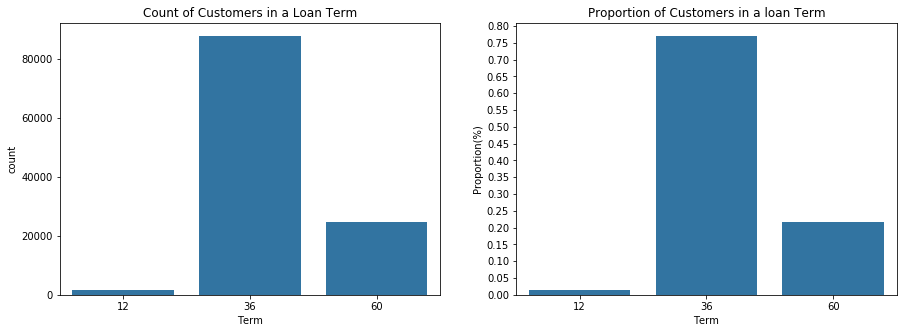

```python
short = loans[loans['Term']== 12]['Term'].count()/loans['Term'].count()
medium = loans[loans['Term']== 36]['Term'].count()/loans['Term'].count()
long = loans[loans['Term']== 60]['Term'].count()/loans['Term'].count()
print('The loan term proportions are:\nShort: {}\tMedium: {}\tLong: {}'.format(short, medium, long))

plt.figure(figsize = [15, 5])
plt.subplot(1,2,1)
color = sb.color_palette()[0]
sb.countplot(data = loans, x = 'Term', color = color)
plt.title('Count of Customers in a Loan Term');

#Plot showing Proportion
plt.subplot(1,2,2)
term_c = loans['Term'].value_counts()
term_sum = loans['Term'].value_counts().sum()
max_ct = loans['Term'].value_counts()[36]
#To get the value of the maximum proportion
max_prp = max_ct / term_sum

#To get Tick Points on the plot
tick_props = np.arange(0, max_prp+0.05, 0.05)
tick_names = ['{:0.2f}'.format(v) for v in tick_props]
sb.countplot(data = loans, x = 'Term', color = color)
plt.title('Proportion of Customers in a loan Term')
plt.yticks(tick_props * term_sum, tick_names)
plt.ylabel('Proportion(%)');
```

> **Observation:**
> - Most (77%) of ProsperLoans Customers are in the Intermediate Term Loan Category which last for 36 months(3years)
> - Long term loans come in around about 22% and Short Term loans(12 months) make up only about 1% of the loans distributions

```python
loans['LoanStatus'].unique()
```

```
array(['Completed', 'Current', 'Past Due (1-15 days)', 'Defaulted',
       'Chargedoff', 'Past Due (16-30 days)', 'Cancelled',
       'Past Due (61-90 days)', 'Past Due (31-60 days)',
       'Past Due (91-120 days)', 'FinalPaymentInProgress',
       'Past Due (>120 days)'], dtype=object)
```

```python
New_LoanStatus = ['Completed', 'FinalPaymentInProgress', 'Current', 'Past Due (1-15 days)', 'Past Due (16-30 days)',
       'Past Due (31-60 days)','Past Due (61-90 days)',
       'Past Due (91-120 days)', 'Past Due (>120 days)', 'Defaulted', 'Chargedoff', 'Cancelled']
new_type = pd.api.types.CategoricalDtype(categories = New_LoanStatus, ordered = True)
loans['LoanStatus'] = loans['LoanStatus'].astype(new_type);
```

```python
loans['LoanStatus'].value_counts().sort_index()
```

```
Completed                 38074
FinalPaymentInProgress      205
Current                   56576
Past Due (1-15 days)        806
Past Due (16-30 days)       265
Past Due (31-60 days)       363
Past Due (61-90 days)       313
Past Due (91-120 days)      304
Past Due (>120 days)         16
Defaulted                  5018
Chargedoff                11992
Cancelled                     5
Name: LoanStatus, dtype: int64
```

### Loan Status

```
113937
```

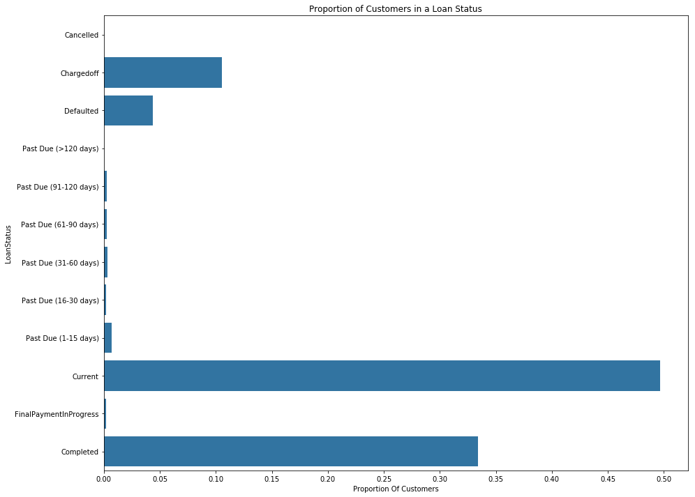

```python
#Plot of the different Proportions each LoanStatus makes in the ProsperLoan Dataset
plt.figure(figsize = [15,12])
L_Ploan = loans['LoanStatus'].value_counts().sort_index(ascending = False)
Ploan_sum = loans['LoanStatus'].value_counts().sum()
max_count = loans['LoanStatus'].value_counts().max()
#To get the value of the maximum proportion of customers in the LoanStatus subset
max_prop = max_count / Ploan_sum
print (Ploan_sum)
#To get Tick Points on the plot
tick_props = np.arange(0, max_prop+0.05, 0.05)
tick_names = ['{:0.2f}'.format(v) for v in tick_props]
order = L_Ploan.index
#Plot
sb.countplot(data = loans,y = 'LoanStatus', color = color, order = order)
plt.title('Proportion of Customers in a Loan Status')
plt.xticks(tick_props * Ploan_sum, tick_names)
plt.xlabel('Proportion Of Customers');
```

#### Interest Rates

```python
# NaN values in the BorrowerAPR column makes it impossible to fix ranges so we create a dataframe for interest
Interest = loans[loans['BorrowerAPR'].isnull() == False]
```

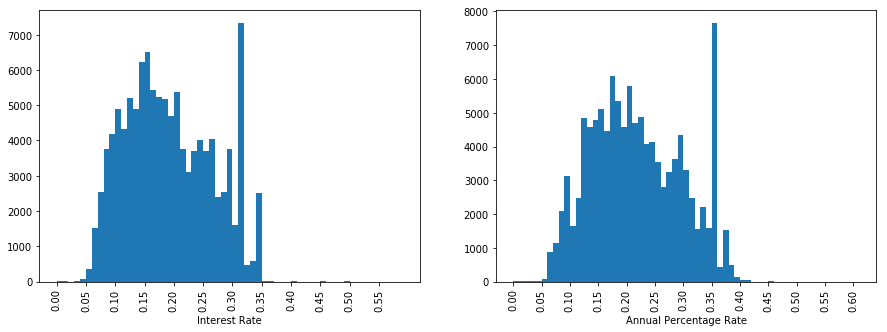

```python
loans['BorrowerRate'].value_counts()
plt.figure(figsize = [15, 5])
def interest():
    plt.subplot(1, 2, 1)
    bins = np.arange(0, loans['BorrowerRate'].max()+0.1, 0.01)
    ticks = np.arange(0,  loans['BorrowerRate'].max()+0.1, 0.05)
    plt.hist(data = loans, x = 'BorrowerRate', bins = bins)
    plt.xticks(ticks, rotation = 90)
    plt.xlabel('Interest Rate')


    plt.subplot(1, 2, 2)
    bins = np.arange(0, Interest['BorrowerAPR'].max()+0.1, 0.01)
    ticks = np.arange(0,  Interest['BorrowerAPR'].max()+0.1, 0.05)
    plt.hist(data = Interest, x = 'BorrowerAPR', bins = bins)
    plt.xticks(ticks, rotation = 90)
    plt.xlabel('Annual Percentage Rate')

interest()
```

> **Observation:**
> - The plots for both BorrowerRate are both similar(Following an approximately normal distribution) we see that while **Interest Rates on loans(BorrowerRate)** has it's highest counts spiking in the **31% - 32%** range, **Annual Percentage Rate(BorrowerAPR)** has it's highest frequency spiking in the **35%-37% range** see the table below

```python
#Borrower Rate Counts
loans.groupby('BorrowerRate')['BorrowerRate'].describe().sort_values('count', ascending = False).head(3)
```

| BorrowerRate | count | mean | std | min | 25% | 50% | 75% | max |
| --- | --- | --- | --- | --- | --- | --- | --- | --- |
| 0.3177 | 3672.0 | 0.3177 | 0.000000e+00 | 0.3177 | 0.3177 | 0.3177 | 0.3177 | 0.3177 |
| 0.3500 | 1905.0 | 0.3500 | 5.552573e-17 | 0.3500 | 0.3500 | 0.3500 | 0.3500 | 0.3500 |
| 0.3199 | 1651.0 | 0.3199 | 0.000000e+00 | 0.3199 | 0.3199 | 0.3199 | 0.3199 | 0.3199 |

```python
#BorrowerAPR count
loans.groupby('BorrowerAPR')['BorrowerAPR'].describe().sort_values('count', ascending = False).head(3)
```

| BorrowerAPR | count | mean | std | min | 25% | 50% | 75% | max |
| --- | --- | --- | --- | --- | --- | --- | --- | --- |
| 0.35797 | 3672.0 | 0.35797 | 0.000000e+00 | 0.35797 | 0.35797 | 0.35797 | 0.35797 | 0.35797 |
| 0.35643 | 1644.0 | 0.35643 | 5.552804e-17 | 0.35643 | 0.35643 | 0.35643 | 0.35643 | 0.35643 |
| 0.37453 | 1260.0 | 0.37453 | 0.000000e+00 | 0.37453 | 0.37453 | 0.37453 | 0.37453 | 0.37453 |

#### Loan Amount

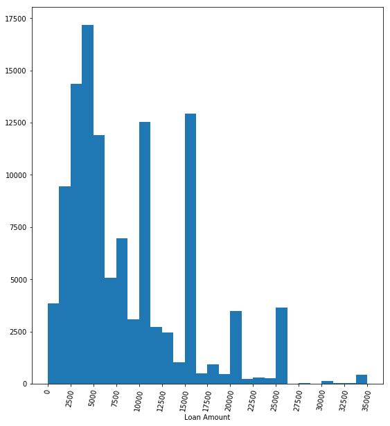

```python
plt.figure(figsize = [20, 10])
def loan_amount():
    plt.subplot(1, 2, 1)
    bins = np.arange(0, loans['LoanOriginalAmount'].max()+1250, 1250)
    ticks = np.arange(0,  loans['LoanOriginalAmount'].max()+1250, 2500)
    plt.hist(data = loans, x = 'LoanOriginalAmount', bins = bins)
    plt.xticks(ticks, rotation = 80)
    plt.xlabel('Loan Amount')

loan_amount()
```

> **Observation**:
> - The loan amount Distribution appeared to be mostly right skewed and is multimodal on close inspection having spikes at different high marks like 10,000, 15000, 20,000 and 25000. **Most of the Loans were on the low range (less than 10000)**

### ProsperRating

```python
loans['ProsperRating (Alpha)'].unique()
```

```
array([nan, 'A', 'D', 'B', 'E', 'C', 'AA', 'HR'], dtype=object)
```

```python
New_Prating = ['AA', 'A','B', 'C', 'D', 'E','HR', 'nan']
r_type = pd.api.types.CategoricalDtype(categories = New_Prating, ordered = True)
loans['ProsperRating (Alpha)'] = loans['ProsperRating (Alpha)'].astype(r_type);
```

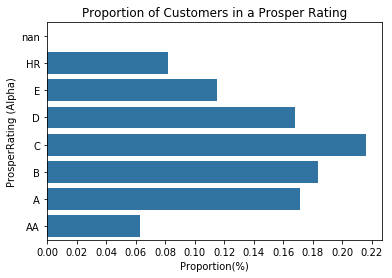

```python
#Plot of the different Proportions each LoanStatus makes in the ProsperLoan Dataset
PRating = loans['ProsperRating (Alpha)'].value_counts().sort_index()
PRating_sum = loans['ProsperRating (Alpha)'].value_counts().sum()
max_ct = loans['ProsperRating (Alpha)'].value_counts().max()
#To get the value of the maximum proportion
max_prp = max_ct / PRating_sum
order = New_Prating[::-1]
#To get Tick Points on the plot
tick_props = np.arange(0, max_prp+0.02, 0.02)
tick_names = ['{:0.2f}'.format(v) for v in tick_props]

#Plot
sb.countplot(data = loans,y = 'ProsperRating (Alpha)', color = color, order = order)
plt.title('Proportion of Customers in a Prosper Rating')
plt.xticks(tick_props * PRating_sum, tick_names)
plt.xlabel('Proportion(%)');
```

```python
pp_alpha = np.sort(loans[loans['ProsperRating (Alpha)'].isnull() == False]['ProsperRating (Alpha)'].unique())
```

> **Observation:** ProsperLoans has a rating scheme for Loans which is: 0-N/A, 1-H/R, 2-E, 3-D, 4-C, 5-B, 6-A and 7-AA
> - Most of the customers (about **22%** of customers) are rated **C(4 points)** closely followed by **B, A, D, E, HR** in descending proportions
> - the smallest proportion **(Only 6%)** of customers are rated **AA(7Points)**

### Credit Score

```python
##Creating A list of Range for Credit Score Range to make it Categorical
Cred_Range = []
for x in loans.index:
    lower = loans['CreditScoreRangeLower'][x].astype(str)
    upper = loans['CreditScoreRangeUpper'][x].astype(str)
    text  = lower + '-' + upper
    Cred_Range.append(text)

loans['CreditRange'] = Cred_Range
cr = np.unique(Cred_Range)
```

```python
###Creating the Categorical Class of Credit Range
Credit_rg = cr
Credit_range = pd.api.types.CategoricalDtype(ordered = True, categories = Credit_rg)
loans['CreditRange'] = loans['CreditRange'].astype(Credit_range)
```

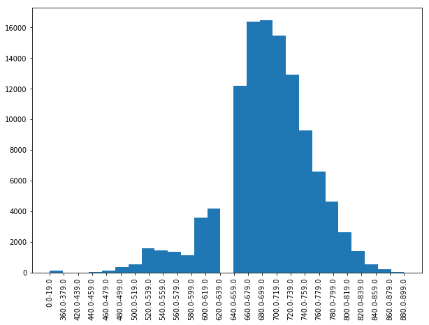

```python
#print(Ploans['CreditRange'].value_counts())
plt.figure(figsize = [10,7])
color = sb.color_palette()[0]
plt.hist(data = loans.query('CreditRange != "nan-nan"').sort_values('CreditRange'), x = 'CreditRange', color = color, bins = 27)
plt.xticks(rotation = 90);
```

> **Observation:**

##### Credit Range Distribution

> The Prosper loans application Credit Range distribution follows an approximately normal distribution(just a very little bit skewed to the left) with few numbers in the **low(Fair)**, **Very Good and Excellent credit ranges.**
> - According to Equifax(equifax.com) a Good Credit range is between 670 to 739. This is where most of our credit range data fall in. Hence, **a normal distribution** even though it appears left skewed
> - Most of the loan applicants (as shown in the plot above) were in the mid(Good) credit range mostly in the **640 - 659, 660 - 679, 680 - 699, 700 - 719, 720 - 739** ranges. The Credit range with the highest numbers was the **680 - 699** range, with **16492** applicants.

#### Income Range

```python
inc_rng = ['$0', '$1-24,999', '$25,000-49,999', '$50,000-74,999', '$75,000-99,999',
           '$100,000+', 'Not employed', 'Not displayed']
inc_type = pd.api.types.CategoricalDtype(categories = inc_rng, ordered = True)
loans['IncomeRange'] = loans['IncomeRange'].astype(inc_type);
```

```
Not employed        806
Not displayed      7741
$75,000-99,999    16916
$50,000-74,999    31050
$25,000-49,999    32192
$100,000+         17337
$1-24,999          7274
$0                  621
Name: IncomeRange, dtype: int64
0.282542106603
```

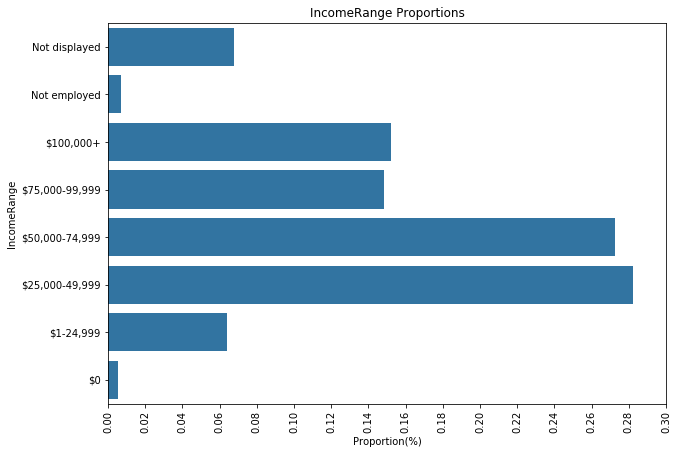

```python
income = loans['IncomeRange'].value_counts().sort_index(ascending = False)
income_sum = loans['IncomeRange'].value_counts().sum()
max_ = loans['IncomeRange'].value_counts().max()
#To get the value of the maximum proportion
m_prp = max_ / income_sum
print(income)
print (m_prp)
#To get Tick Points on the plot
tick_props = np.arange(0, m_prp+0.02, 0.02)
tick_names = ['{:0.2f}'.format(v) for v in tick_props]
order = inc_rng[::-1]
plt.figure(figsize = [10,7])
color = sb.color_palette()[0]
sb.countplot(data = loans, y = 'IncomeRange', color = color, order = order)
plt.xticks(tick_props * income_sum, tick_names, rotation = 90)
plt.xlabel('Proportion(%)')
plt.title('IncomeRange Proportions');
```

> **Income Range Distribution**
> - Over 90% of the customers have income of at least **1000 dollars**.
> - The majority being in the midrange(over **28%** within the **25,000-49,999dollars** range and **27%** of customers making **50,000-74999dollars**)

#### Borrower's State Distribution

```
0.135738134327
```

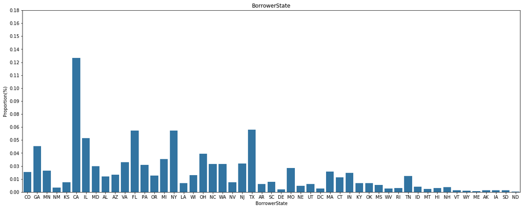

```python
state_c = loans['BorrowerState'].value_counts()
state_sum = loans['BorrowerState'].value_counts().sum()
max_ = loans['BorrowerState'].value_counts()[0]
#To get the value of the maximum proportion
m_prp = max_ / state_sum
print (m_prp)
#To get Tick Points on the plot
tick_props = np.arange(0, m_prp+0.05, 0.0125)
tick_names = ['{:0.2f}'.format(v) for v in tick_props]

plt.figure(figsize = [20,7.5])
color = sb.color_palette()[0]
sb.countplot(data = loans, x = 'BorrowerState', color = color)
plt.yticks(tick_props * income_sum, tick_names)
plt.ylabel('Proportion(%)')
plt.title('BorrowerState');
```

> **Observation:**
> - The state with the highest Prosper loan applicants is **California** State, with approximately **13.5%** of Prosper loan applicants. Other States with high proportion of applicants from high to low counts were: **Texas(6.3%), New York(6.2%), Florida(6.2%), Illinois(5.4%)** and **Georgia(4.6%)**.

#### Debt-To-Income Ratio

```python
DtoIR = loans[loans['DebtToIncomeRatio'].isnull() == False]
```

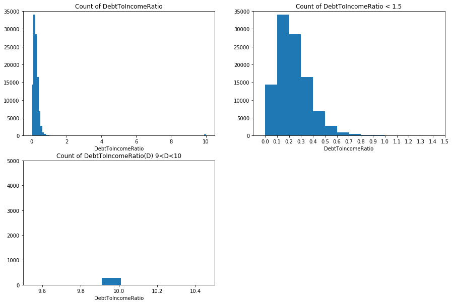

```python
### Debt to Income Ratio
plt.figure(figsize= [15, 10])
plt.subplot(2, 2, 1)
color = sb.color_palette()[0]
plt.hist(data = DtoIR, x = 'DebtToIncomeRatio', color = color, bins = 100)
plt.ylim(-1, 35000)
plt.title('Count of DebtToIncomeRatio')
plt.xlabel('DebtToIncomeRatio');

plt.subplot(2, 2, 2)
color = sb.color_palette()[0]
plt.hist(data = DtoIR, x = 'DebtToIncomeRatio', color = color, bins = 100)
plt.xticks(np.arange(0, loans['DebtToIncomeRatio'].max()+0.1, 0.1))
plt.xlim(-0.1, 1.5)
plt.ylim(-1, 35000)
plt.title('Count of DebtToIncomeRatio < 1.5')
plt.xlabel('DebtToIncomeRatio');

plt.subplot(2, 2, 3)
color = sb.color_palette()[0]
plt.hist(data = DtoIR, x = 'DebtToIncomeRatio', color = color, bins = 100)
plt.xlim(9.5, 10.5)
plt.ylim(-1, 5000)
plt.title('Count of DebtToIncomeRatio(D) 9<D<10')
plt.xlabel('DebtToIncomeRatio');
```

> **Observation:**
> - The DebtToIncomeRatio plot is right skewed showing that most of the applicants have quite enough monthly income to cover their monthly debt payments. with the most frequency having to pay less than **10%-40%** of their monthly income on debt payments.
> - Although very few there were DebtToIncomeRatios as high as **100%** and higher which would mean that they would have to spend all their monthly income on debt payments. this could have been an error in data entry.

#### Listing Category

```python
#Creating Listing Category Feature from ListingCategory(numeric)
l_nume = [0, 1, 2, 3, 4, 5, 6, 7 ,8 ,9 ,10, 11, 12, 13, 14, 15, 16, 17, 18, 19, 20]
l_cat = ['Not Available','Debt Consolidation', 'Home Improvement', 'Business','Personal Loan', 'Student Use', 'Auto','Other', 'Baby&Adoption','Boat', 'Cosmetic Procedure', 'Engagement Ring', 'Green Loans', 'Household Expenses', 'Large Purchases', 'Medical/Dental', 'Motorcycle','RV', 'Taxes', 'Vacation', 'Wedding Loans']
cat = []
for x in loans.index:
    for y in l_nume:
        if loans['ListingCategory (numeric)'][x] == l_nume[y]:
            cat.append(l_cat[y])
loans['ListingCategory'] = cat
```

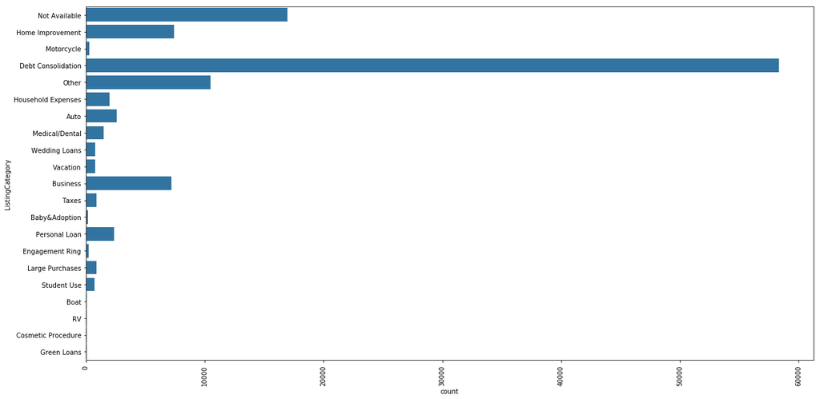

```python
plt.figure(figsize = [20, 10])
sb.countplot(data = loans, y= 'ListingCategory', color = color)
plt.xticks(rotation = 90);
```

### Discuss the distribution(s) of your variable(s) of interest. Were there any unusual points? Did you need to perform any transformations?

> > **Original Loan Amount:**
> > - The loan amount Distribution appeared to be mostly right skewed and is multimodal on close inspection having spikes at different high marks like 10,000, 15000, 20,000 and 25000. Most of the Loans were on the low range (less than 10000)

> > **CreditRange (Combination of CreditScoreRatingLower and CreditScoreRatingUpper)**
> > - The Prosper loans application Credit Range distribution follows an approximately normal distribution(just a very little bit skewed to the left) with few numbers in the low(Fair), Very Good and Excellent credit ranges. **Note:** *According to Equifax(equifax.com) a Good Credit range is between 670 to 739. This is where most of our credit range data fall in. Hence, a normal distribution Most of the loan applicants (as shown in the plot above) were in the mid(Good) credit range mostly in the 640 - 659, 660 - 679, 680 - 699, 700 - 719, 720 - 739 ranges. The Credit range with the highest numbers was the 680 - 699 range, with 16492 applicants.*

### Of the features you investigated, were there any unusual distributions? Did you perform any operations on the data to tidy, adjust, or change the form of the data? If so, why did you do this?

> > **CreditRange:** The CreditRange feature was formed by combining the Lower and Upper Credit Score Ratings in the original dataset and made into a categorical datatype for exploration.

## Bivariate Exploration

> In this section, investigate relationships between pairs of variables in your data. Make sure the variables that you cover here have been introduced in some fashion in the previous section (univariate exploration).

### What Factors or Features Affect the Loan Status?

```
Text(0.5,1,'Mean Interest Rate by Loan Status')
```

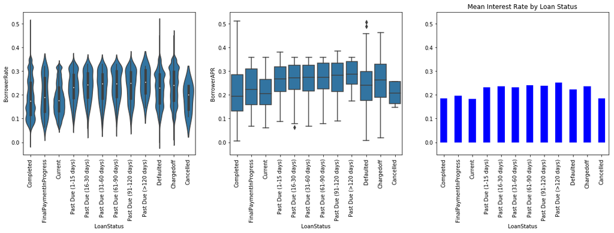

```python
plt.figure(figsize = [20, 5])
base_color = sb.color_palette()[0]

# left plot: violin plot
plt.subplot(1, 3, 1)
ax1 = sb.violinplot(data = loans, x = 'LoanStatus', y = 'BorrowerRate', color = base_color)
plt.xticks(rotation =90);

# center plot: box plot
plt.subplot(1, 3, 2)
sb.boxplot(data = loans, x = 'LoanStatus', y = 'BorrowerAPR', color = base_color)
plt.ylim(ax1.get_ylim()) # set y-axis limits to be same as left plot
plt.xticks(rotation =90);

plt.subplot(1, 3, 3)
LoanStatus = loans.groupby('LoanStatus')['BorrowerRate'].mean()
LoanStatus.plot(kind = 'bar', color = 'b')
plt.ylim(ax1.get_ylim())
plt.title('Mean Interest Rate by Loan Status')
```

> **Observation**:
> - Most of the Loans that are **Current**, **Completed**, **Cancelled** or are making final payments(**FinalPaymentsInProgress**) have on the average lower Interest rates with few outliers(exceptions to the case).
> - Loans that are **Past due**, **Defaulted** or **Charged off** have on the average higher Interest rates. Even, On closer inspection we can even see that the average interest rates for LoanStatus that are **past due** are slightly higher with higher past due days. We see that Past Due(>120 days) has the highest mean Interest Rate

#### Do IncomeRange and Loan Term Affect Loan Status?

> **Income Range**

```python
# Remove Income Range entries that are not displayed or are $0
Inc_Range = loans.query('IncomeRange != ["Not displayed","$0"]')['IncomeRange'].unique()
Inc_Range = np.sort(Inc_Range)
```

```python
loans.query('LoanStatus != "NaN"')['LoanStatus'].sort_index().unique ()
```

```
[Completed, Current, Past Due (1-15 days), Defaulted, Chargedoff, ..., Past Due (61-90 days), Past Due (31-60 days), Past Due (91-120 days), FinalPaymentInProgress, Past Due (>120 days)]
Length: 12
Categories (12, object): [Completed < FinalPaymentInProgress < Current < Past Due (1-15 days) ... Past Due (>120 days) < Defaulted < Chargedoff < Cancelled]
```

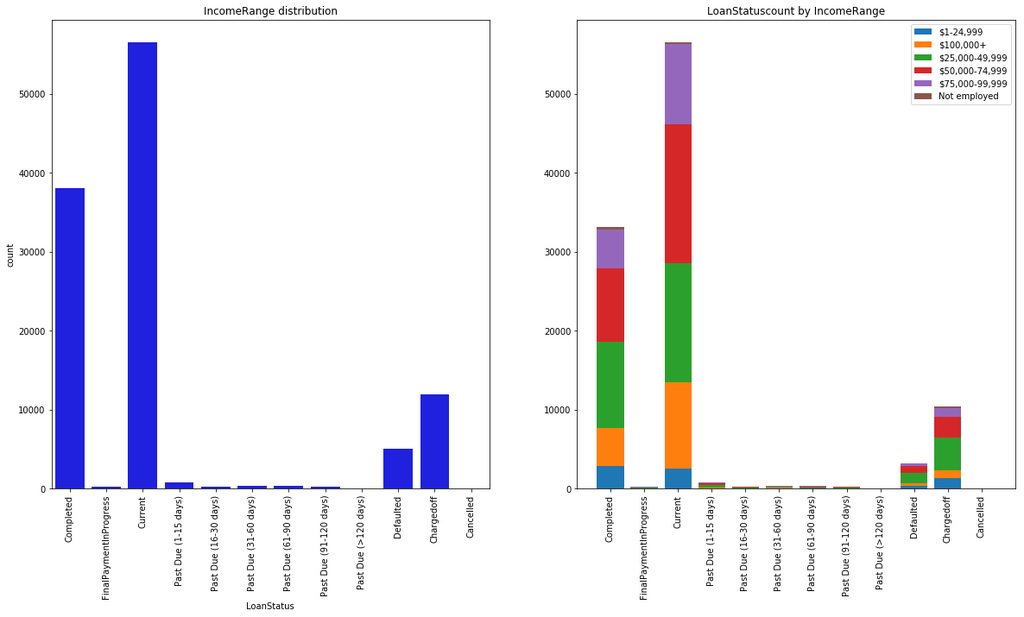

```python
plt.figure(figsize = [20, 10])
plt.subplot(1,2,1)
sb.countplot(data = loans, x = 'LoanStatus', color = 'b')
plt.xticks(rotation = 90)
plt.title('IncomeRange distribution')

plt.subplot(1, 2, 2)
cat2_order = Inc_Range
cat1_order  = New_LoanStatus
#np.sort(loans.query('LoanStatus != "NaN"')['LoanStatus'].unique())

baselines = np.zeros(len(cat1_order))
# for each second-variable category:
for i in range(len(cat2_order)):
    # isolate the counts of the first category,
    cat2 = cat2_order[i]
    inner_counts = loans[loans['IncomeRange'] == cat2]['LoanStatus'].value_counts().sort_index()
    # then plot those counts on top of the accumulated baseline
    plt.bar(x = np.arange(len(cat1_order)), height = inner_counts[cat1_order],bottom = baselines)
    baselines += inner_counts[cat1_order]

plt.xticks(np.arange(len(cat1_order)), cat1_order, rotation = 90)
plt.legend(cat2_order, loc = 'upper right')
plt.title('LoanStatuscount by IncomeRange');
```

> **Observation:**
> - Here we see that Loan is likely to be completed if the borrower has a source of income, but there is no special relationship between high income and a likelyhood to complete, make timely payments or default. This is because we see all income ranges distributed across all loan status.

#### ProsperRating and LoanStatus

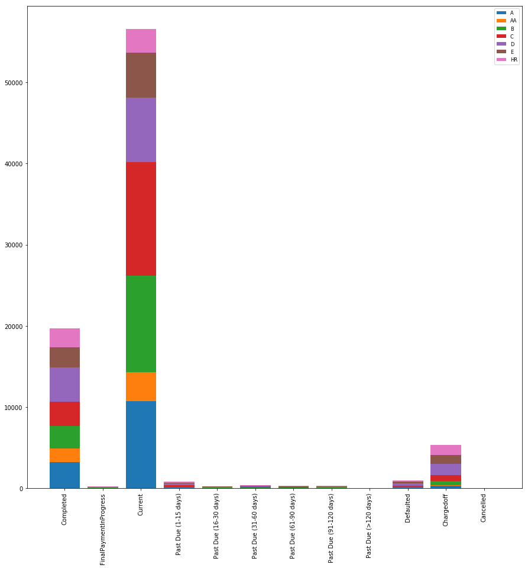

```python
cat2_order = np.sort(loans[loans['ProsperRating (Alpha)'].isnull() == False]['ProsperRating (Alpha)'].unique())
cat1_order = New_LoanStatus
#loans.query('LoanStatus != "NaN"')['LoanStatus'].unique()

plt.figure(figsize = [15, 15])
baselines = np.zeros(len(cat1_order))
# for each second-variable category:
for i in range(len(cat2_order)):
    # isolate the counts of the first category,
    cat2 = cat2_order[i]
    inner_counts = loans[loans['ProsperRating (Alpha)'] == cat2]['LoanStatus'].value_counts()
    # then plot those counts on top of the accumulated baseline
    plt.bar(x = np.arange(len(cat1_order)), height = inner_counts[cat1_order],bottom = baselines)
    baselines += inner_counts[cat1_order]

plt.xticks(np.arange(len(cat1_order)), cat1_order, rotation = 90)
plt.legend(cat2_order, loc = 'upper right', fontsize = 'small')
```

> **Observation:** We see that all ProsperRatings are represented in the Completed LoanStatus column. Even though we see that those rated AA and A have most of their proportions for Completed and Current Loan Status.

> **Loan Term and Loan Status**

```python
term = loans['Term'].unique()
term = np.sort(term)
```

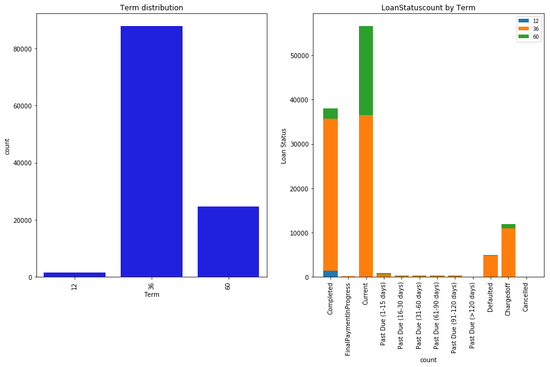

```python
plt.figure(figsize = [15,8])
plt.subplot(1,2,1)
sb.countplot(data = loans, x = 'Term', color = 'b')
plt.xticks(rotation = 90)
plt.title('Term distribution');

plt.subplot(1, 2, 2)
cat2_order = term
cat1_order = New_LoanStatus
#loans.query('LoanStatus != "NaN"')['LoanStatus'].unique()

baselines = np.zeros(len(cat1_order))
# for each second-variable category:
for i in range(len(cat2_order)):
    # isolate the counts of the first category,
    cat2 = cat2_order[i]
    inner_counts = loans[loans['Term'] == cat2]['LoanStatus'].value_counts()
    # then plot those counts on top of the accumulated baseline
    plt.bar(x = np.arange(len(cat1_order)), height = inner_counts[cat1_order],bottom = baselines)
    baselines += inner_counts[cat1_order]

plt.xticks(np.arange(len(cat1_order)), cat1_order, rotation = 90)
plt.legend(cat2_order, loc = 'upper right', fontsize = 'small')
plt.title('LoanStatuscount by Term')
plt.xlabel('count')
plt.ylabel('Loan Status');
```

```python
loans['Term'][loans['LoanStatus'] == 'Completed'].value_counts()/loans['Term'].value_counts()
```

```
36    0.389619
60    0.098757
12    0.898389
Name: Term, dtype: float64
```

```python
print('These plots show the proportion of each Loan term in each Loan Status')
Loan_Stat = np.sort(loans['LoanStatus'].unique())
plt.figure(figsize = [15, 30])
plt.tight_layout()
for i in range(len(Loan_Stat)):
    plt.subplot(6, 2, i+1)
    Completed = loans['Term'][loans['LoanStatus'] == Loan_Stat[i]].value_counts()/loans['Term'].value_counts().sort_values()
    plt.plot(Completed.index, Completed.values)
    plt.xlabel(Loan_Stat[i])
    plt.ylabel('proportion (%)')
```

[output not shown]

```
These plots show the proportion of each Loan term in each Loan Status
```

> **Observation**:
> - A great amount(89%) of the Short Term loan payments. have **Completed Status.** Compared to only 38% of Medium Term and only 9% of Long Term Loans
> - The **shorter** the **Term** the more likely the loan is completed, **Medium term loans** are mostly likely to be **defaulted or Charged Off** and **Long Term** loans are most likely to have **due payments** followed by **Medium Term** Loans
> - The long term loan payments are mostly split between **Current** Payments, **Completed** Payments and **ChargeOffs, with the highest frequency making up Current payments**, with relatively smaler frequencies in Past due and Default payments.
> - The Medium Term Loans are more distributed among all loan status but still have their highest frequency in **Completed**, **Current** Payments and **Chargeoffs** with the highest frequency in **Current Payments**.

### Stated Monthly Income, Debt-To-Income Ratio and BorrowerRate

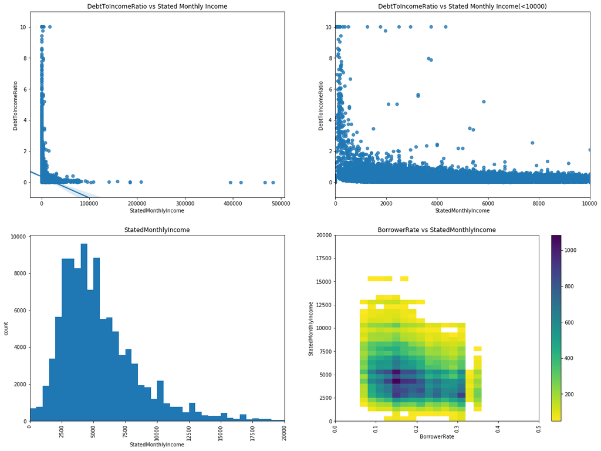

```python
plt.figure(figsize= [20,15])

plt.subplot(2, 2, 1)
plt.ylim(-1 , 11)
sb.regplot(data = DtoIR, x = 'StatedMonthlyIncome', y = 'DebtToIncomeRatio')
plt.title('DebtToIncomeRatio vs Stated Monthly Income')
plt.xlabel('StatedMonthlyIncome')
plt.ylabel('DebtToIncomeRatio');

plt.subplot(2, 2, 2)
sb.regplot(data = DtoIR, x = 'StatedMonthlyIncome', y = 'DebtToIncomeRatio')
plt.ylim(-1, 11)
plt.xlim(0, 10000)
plt.title('DebtToIncomeRatio vs Stated Monthly Income(<10000)')
plt.xlabel('StatedMonthlyIncome')
plt.ylabel('DebtToIncomeRatio')

plt.subplot(2,2,3)
bins = np.arange(0, DtoIR['StatedMonthlyIncome'].max(), 500)
plt.hist(data = DtoIR, x = 'StatedMonthlyIncome', bins = bins)
plt.xlim(0, 20000)
plt.xticks(rotation = 90)
plt.xlabel('StatedMonthlyIncome')
plt.ylabel('count')
plt.title('StatedMonthlyIncome');

plt.subplot(2, 2 , 4)
bins_y = np.arange(0,20000, 500)
bins_x = np.arange(0, DtoIR['BorrowerRate'].max()+0.02, 0.02)
plt.hist2d(data = DtoIR, y = 'StatedMonthlyIncome', x = 'BorrowerRate', cmin = 50, cmap = 'viridis_r', bins = [bins_x, bins_y] )
plt.ylim(0, 20000)
plt.xticks(rotation = 90)
plt.colorbar()
plt.title('BorrowerRate vs StatedMonthlyIncome')
plt.ylabel('StatedMonthlyIncome')
plt.xlabel('BorrowerRate');
```

> - As expected we see that the higher the Stated Monthly Income the Lower the Debt to Income Ratio
> - We see a right skewed Stated Monthly income showing of course that most of the loan applicants are in the lower income range and a few people on the higher income range.
> - And although slight and not very obvious we see that a higher stated monthly income has less Interest rate on their loans. Not a strong one though. Further investigation into borrower rate will be needed.

### Is there any clear relationship between debt to Income Ratio and Interest Rates or Loan Amount and Annual Interest on Loans(BorrowerAPR)?

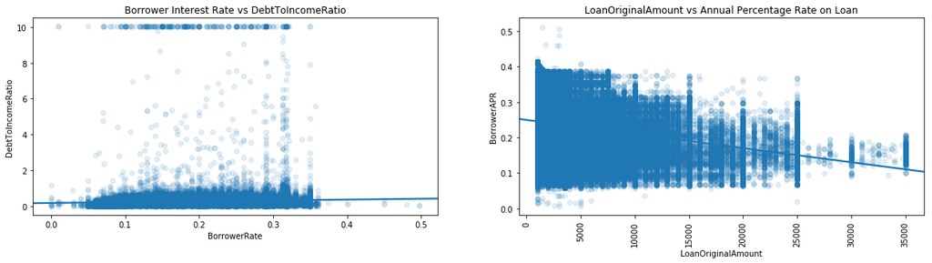

```python
plt.figure(figsize = [20,10])
plt.subplot(2, 2, 1)
sb.regplot(data = DtoIR, x = 'BorrowerRate', y = 'DebtToIncomeRatio', scatter_kws ={'alpha': 1/8})
plt.title('Borrower Interest Rate vs DebtToIncomeRatio')
plt.ylabel('DebtToIncomeRatio')

plt.subplot(2, 2, 2)
sb.regplot(data = DtoIR, y = 'BorrowerAPR', x = 'LoanOriginalAmount', scatter_kws ={'alpha': 1/8})
plt.xticks(rotation = 90)
plt.title('LoanOriginalAmount vs Annual Percentage Rate on Loan')
plt.xlabel('LoanOriginalAmount')
plt.ylabel('BorrowerAPR');
```

> **Observation**:
> - Although not very obvious we can see a very slightly positive correlation between DebtToIncomeRatio and BorrowerRate.
> - We will need to investigate **BorrowerRate** further to find other features that show a **strong Correlation.**
> - Also we see a downward negative trend between annual percentage interest (borrowerAPR) and Initial Loan amount. From this we can say that the higher the Loan amount the lower the Borrower's Annual Percentage Rate on the Loan.

**We will now Investigate Other features to find a relationship with BorrowerRate**

### 2. Is the Interest Rate on the Loan affected by other features like Income range, Loan term and Credit range?

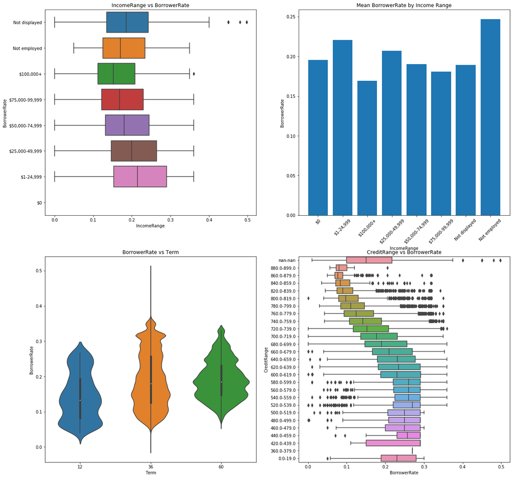

```python
plt.figure(figsize = [20,20])
plt.tight_layout()
plt.subplot(2, 2, 1)
order = inc_rng[::-1]
sb.boxplot(data = DtoIR, y = 'IncomeRange', x = 'BorrowerRate', order = order);
plt.title('IncomeRange vs BorrowerRate')
plt.ylabel('BorrowerRate')
plt.xlabel('IncomeRange');

plt.subplot(2, 2, 2)
inc_range = loans.groupby('IncomeRange')['BorrowerRate'].mean().sort_index()
plt.bar(inc_range.index, inc_range.values)
plt.title('Mean BorrowerRate by Income Range')
plt.ylabel('BorrowerRate')
plt.xlabel('IncomeRange')
plt.xticks(rotation = 45);

plt.subplot(2, 2, 3)
sb.violinplot(data = DtoIR, x = 'Term', y = 'BorrowerRate');
plt.title('BorrowerRate vs Term')
plt.xlabel('Term')
plt.ylabel('BorrowerRate');

plt.subplot(2, 2, 4)
order = np.sort(loans.CreditRange.unique())[::-1]
sb.boxplot(data = loans, x = 'BorrowerRate', y = 'CreditRange', order = order);
plt.title('CreditRange vs BorrowerRate')
plt.xlabel('BorrowerRate')
plt.ylabel('CreditRange');
```

> **Observation**:
> - **IncomeRange vs BorrowerRate:** Although not easily detected on the average people with higher income range tend to have lower borrower interest rates this is probably due to the fact that Loan companies percieve them as low risk customers since a higher income may mean higher probability of making loan payments.
> - **Term vs BorrowerRate:** Short term loans( a year or less) had lower interest rates on the average. For medium and long term loans(36months and >60months respectively) we observe that long term(60month) has just very slightly higher interest rates on the average than medium term(36months). We also see that medium term loans had more spread in interest rates recording highest and lowest interest rates.
> - **CreditRange vs BorrowerRate:** As can be clearly seen in the box plot above, On the average, the higher the credit the lower the interest on the loan. This is probably due to the fact that lenders will usually charge higher interest on high risk loans and since a higher credit rating means that the customer mostly pay of their debts, it means people with higher Credit rating are low risk borrowers. Although there are some outliers, the boxplot summary simply shows that for a majority of cases and on the average, Higher credit rating means low interest.

#### Here A relationship between original loan amount and Interest on loan(BorrowerRate) is investigated further with a heatmap and scatterplot

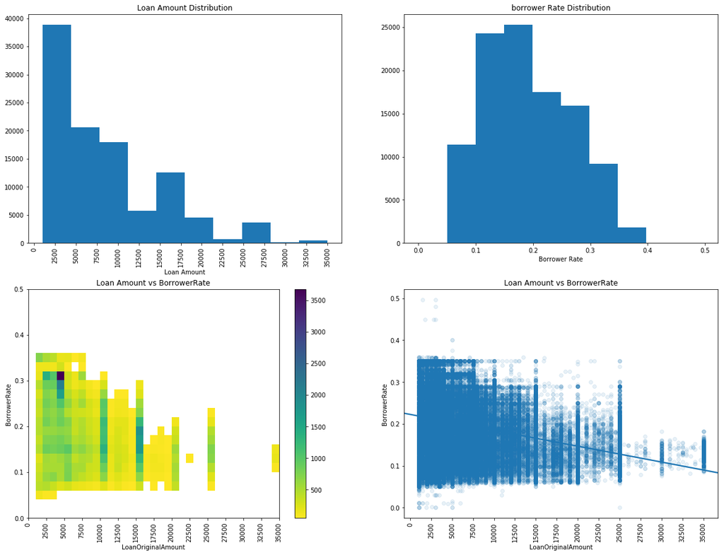

```python
#Distribution of Original Loan Amount
plt.figure(figsize = [20,15])
plt.subplot(2,2,1)
ticks = np.arange(0, DtoIR['LoanOriginalAmount'].max()+2500, 2500)
plt.hist(data = DtoIR, x = 'LoanOriginalAmount')
plt.xticks(ticks, rotation = 90)
plt.xlabel('Loan Amount')
plt.title('Loan Amount Distribution');

#Distribution of BorrowerRate
plt.subplot(2,2,2)
plt.hist(data = DtoIR, x = 'BorrowerRate')
plt.xlabel('Borrower Rate')
plt.title('borrower Rate Distribution');


#Comparison of Interest Rate on Loan and Original Loan Amount in heatmap
plt.subplot(2, 2 , 3)
bins_x = np.arange(0, DtoIR['LoanOriginalAmount'].max()+ 1000, 1000)
bins_y = np.arange(0, DtoIR['BorrowerRate'].max()+0.02, 0.02)
plt.hist2d(data = DtoIR, x = 'LoanOriginalAmount', y = 'BorrowerRate', cmin = 50, cmap = 'viridis_r', bins = [bins_x, bins_y] )
ticks = np.arange(0, DtoIR['LoanOriginalAmount'].max()+2500, 2500)
plt.xticks(ticks, rotation = 90)
plt.colorbar()
#plt.ylim(-1, 400);
plt.title('Loan Amount vs BorrowerRate')
plt.xlabel('LoanOriginalAmount')
plt.ylabel('BorrowerRate');

#Comparison of Interest Rate on Loan and Original Loan Amount in Scatter Plot

plt.subplot(2,2, 4)
bins_x = np.arange(0, DtoIR['LoanOriginalAmount'].max()+ 1000, 1000)
bins_y = np.arange(0, DtoIR['BorrowerRate'].max()+0.02, 0.02)
sb.regplot(data = DtoIR, x = 'LoanOriginalAmount', y = 'BorrowerRate', scatter_kws = {'alpha': 1/10})
ticks = np.arange(0, DtoIR['LoanOriginalAmount'].max()+2500, 2500)
plt.xticks(ticks, rotation = 90)
plt.title('Loan Amount vs BorrowerRate')
plt.xlabel('LoanOriginalAmount')
plt.ylabel('BorrowerRate');
```

> **Observation**: It is observable from the heat map and Scatter plots that People who got higher amount in loans generally had lower interest on their loans. From the heat map while we see a fading in colour from higher interest rates to lower signifying that a greater proportion of people with lower original loan amounts have higher interest rate, we can see the direct opposite with higher loan amounts.

### Talk about some of the relationships you observed in this part of the investigation. How did the feature(s) of interest vary with other features in the dataset?

> Here we see a correlation between Our Features of Interest and other features:

> **Loan Status**:
> - Most of the Loans that are **Current**, **Completed**, **Cancelled** or are making final payments (**FinalPaymentsInProgress**) have on the average, lower Interest rates. Loans that are **Past due**, **Defaulted** or **Charged off** have on the average higher Interest rates. The average interest rates for LoanStatus that are **past due** are slightly higher with higher past due days. With **Past Due(>120 days)** having the highest mean Interest Rate.
> - A great amount(89%) of the Short Term loan payments. have **Completed Status.** Compared to only 38% of Medium Term and only 9% of Long Term Loans. We see that the **shorter** the **Term** the more likely the loan is completed, **Medium term loans** are the most likely to be **defaulted or Charged Off** and **Long Term** loans are the most likely to have **due payments** followed by **Medium Term** Loans.
> - The Loan Status is likely to be completed or Current when they are rated AA or A and we know that high CreditRange plays a role in being rated high(AA or A) in prosper ratings (alpha).

> **BorrowerRate**
> - We see that the interest rate on loans(BorrowerRate) mostly reduces with higher Original Loan amounts borrowed.
> - We see the average and median interest rate on loans(BorrowerRate) Increasing with decreasing income range.
> - Short term loans( a year or less) have lower interest rates on the average. long term(60month) loans have just very slightly higher interest rates on the average than medium term(36months). Medium term loans have more spread in interest rates recording highest and lowest interest rates.
> - Lower Credit ranges were also associated with higher interest rates. As we see in a boxplot that median and average interest rates reduced with higher Credit scores

### Did you observe any interesting relationships between the other features (not the main feature(s) of interest)?

> We see that there is a little correlation between Debt-To-Income-Ratio and StatedMonthly Income. The higher the stated monthly income the lower the debt-to-income ratio!

## Multivariate Exploration

> Create plots of three or more variables to investigate your data even further. Make sure that your investigations are justified, and follow from your work in the previous sections.

#### Credit Range, BorrowerRate and Loan Term

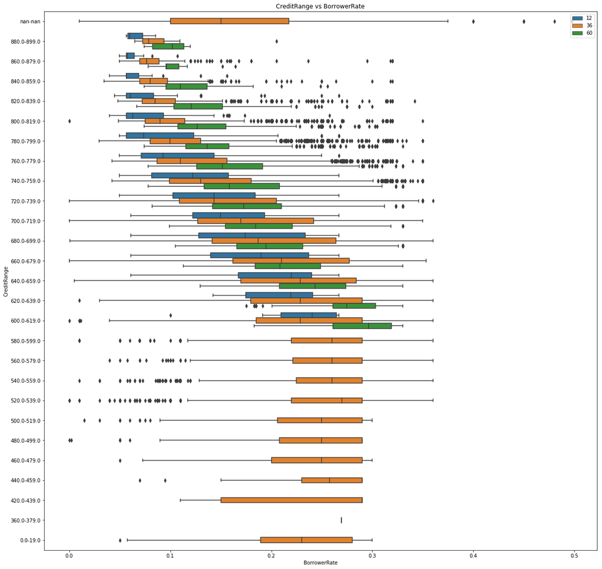

```python
plt.figure(figsize = [20,20])
order = np.sort(loans.CreditRange.unique())[::-1]
sb.boxplot(data = loans, x = 'BorrowerRate', y = 'CreditRange', hue = 'Term', order = order);
plt.title('CreditRange vs BorrowerRate')
plt.xlabel('BorrowerRate')
plt.ylabel('CreditRange')
plt.legend(loc = 'upper right')
```

> **Observation**:
> - We know from previous visualisations that a higher credit rating mostly means lower interest rate on the loan(low BorrowerRate). Now we can see that for the same credit ratings, Short tem loans have lower interest rates than mid term and long term loans on the average. Long term loans have the highest interest rates for the same credit ratings on the average.

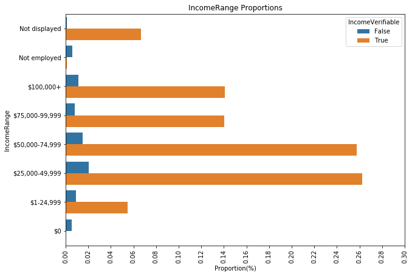

```python
plt.figure(figsize = [10,7])
color = sb.color_palette()[0]

income = loans['IncomeRange'].value_counts().sort_index()
income_sum = loans['IncomeRange'].value_counts().sum()
max_ = loans['IncomeRange'].value_counts().max()
#To get the value of the maximum proportion
m_prp = max_ / income_sum
#To get Tick Points on the plot
tick_props = np.arange(0, m_prp+0.02, 0.02)
tick_names = ['{:0.2f}'.format(v) for v in tick_props]
order = inc_rng[::-1]
sb.countplot(data = loans, y = 'IncomeRange', hue = 'IncomeVerifiable', order = order)
plt.xticks(tick_props * income_sum, tick_names, rotation = 90)
plt.xlabel('Proportion(%)')
plt.title('IncomeRange Proportions');
```

```python
sb.relplot(data = loans, x = 'LoanOriginalAmount', y= 'BorrowerRate', hue = 'ProsperRating (Alpha)')
```

[output not shown]

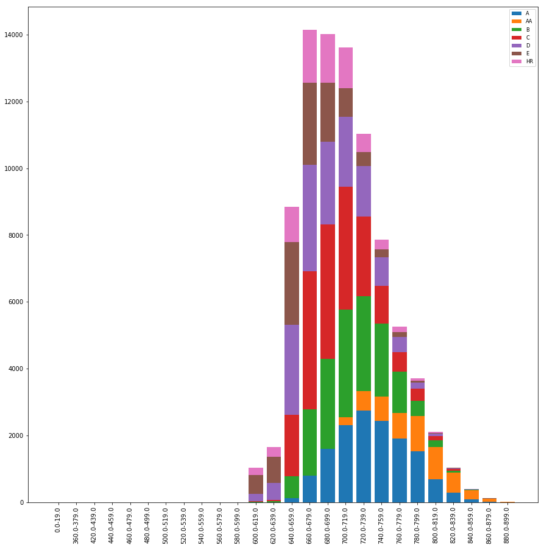

```python
cat2_order = np.sort(loans[loans['ProsperRating (Alpha)'].isnull() == False]['ProsperRating (Alpha)'].unique())
cat1_order = loans.query('CreditRange != "nan-nan"').sort_values('CreditRange')['CreditRange'].unique()

plt.figure(figsize = [15, 15])
baselines = np.zeros(len(cat1_order))
# for each second-variable category:
for i in range(len(cat2_order)):
    # isolate the counts of the first category,
    cat2 = cat2_order[i]
    inner_counts = loans[loans['ProsperRating (Alpha)'] == cat2]['CreditRange'].value_counts()
    # then plot those counts on top of the accumulated baseline
    plt.bar(x = np.arange(len(cat1_order)), height = inner_counts[cat1_order],bottom = baselines)
    baselines += inner_counts[cat1_order]

plt.xticks(np.arange(len(cat1_order)), cat1_order, rotation = 90)
plt.legend(cat2_order, loc = 'upper right', fontsize = 'small')
```

### Summary of Multivariate Analysis

> **Borrower Rates:**

> > We know from previous visualisations that a higher credit rating mostly means lower interest rate on the loan(low BorrowerRate). Now we can see that for the same credit ratings, Short tem loans have lower interest rates than mid term and long term loans on the average. Long term loans have the highest interest rates for the same credit ratings on the average.

> **LoanStatusOutcome:**

> > > **Note:** We know that CreditRange has a lot to do with ProsperRatings with higher Credit Scores being more in the AA and A prosperRating

## Conclusions

> **BorrowerRate:**
> > - Interest rates have a negative correlation with credit range. We see that the higher the CreditRange(Which means higher ProsperRating) the lower the interest rates on loans.
> > - We see the average and median interest rate on loans(BorrowerRate) Increasing with decreasing income range.
> > - Short term loans( a year or less) have lower interest rates on the average. long term(60month) loans have just very slightly higher interest rates on the average than medium term(36months). Medium term loans have more spread in interest rates recording highest and lowest interest rates.

> **LoanStatus:**
> > - Most of the Loans that are Current, Completed, Cancelled or are making final payments (FinalPaymentsInProgress) have on the average, lower Interest rates. Loans that are Past due, Defaulted or Charged off have on the average higher Interest rates. The average interest rates for LoanStatus that are past due are slightly higher with higher past due days. With Past Due(>120 days) having the highest mean Interest Rate.
> > - Loan Term plays a huge role with Loan Status. A great amount(89%) of the Short Term loan payments. have Completed Status. Compared to only 38% of Medium Term and only 9% of Long Term Loans. We see that the shorter the Term the more likely the loan is completed, Medium term loans are the most likely to be defaulted or Charged Off and Long Term loans are the most likely to have due payments followed by Medium Term Loans.
> > - The Loan Status is likely to be completed or Current when they are rated AA or A and we know that high CreditRange plays a role in being rated high(AA or A) in prosper ratings (alpha).

> **OriginalLoanAmount:**
> > - the higher the original loan amount the less likely the payments are to be completed.
> > - Higher original loan amounts have slightly lower interest rates. and they are mostly associated with long term loans(60 months)